# Analyzing Movie Ratings

This R Notebook will focus on determining the relationship between movie ratings and user votes, from IMDB, for the top 30 movies between March and July 2020. Using web scraping techniques, various details for the movies will be acquired, in order to visualize if the highest rated movies have the most user votes.

```r
library(rvest)
library(dplyr)
library(ggplot2)

url <- "http://dataquestio.github.io/web-scraping-pages/IMDb-DQgp.html"

wp_content <- read_html(url)
```

The *rvest*, *dplyr*, and *ggplot2* packages were loaded to efficiently web scrap, manipulate the acquried data, and plot the results, respectively.

Additionally, the url was loaded to save it for the entire project. Creating the variable, *wp_content*, saves the content from the webpage that contains the top 30 movies from March to July 2020.

```r
titles <- wp_content %>%
  html_nodes(".lister-item-header a") %>%
  html_text()

  print(titles)
```

```
 [1] "Mulan"                                           "The Call"
 [3] "Greenland"                                       "Don't Listen"
 [5] "Unhinged"                                        "Ava"
 [7] "The Hunt"                                        "Ghosts of War"
 [9] "Hamilton"                                        "The Old Guard"
[11] "The Secret: Dare to Dream"                       "The Outpost"
[13] "Extraction"                                      "Train to Busan Presents: Peninsula"
[15] "Greyhound"                                       "The King of Staten Island"
[17] "A Quiet Place Part II"                           "Bloodshot"
[19] "The Dark and the Wicked"                         "Arkansas"
[21] "The Rental"                                      "Trolls World Tour"
[23] "Sputnik"                                         "Eurovision Song Contest: The Story of Fire Saga"
[25] "Inheritance"                                     "Spenser Confidential"
[27] "The Tax Collector"                               "The Way Back"
[29] "The Silencing"                                   "Archive"
```

```r
release_years <- wp_content %>%
  html_nodes(".text-muted.unbold") %>%
  html_text() %>% readr::parse_number()

  print(release_years)
```

```
 [1] 2020 2020 2020 2020 2020 2020 2020 2020 2020 2020 2020 2020 2020 2020 2020 2020 2020 2020 2020 2020 2020
[22] 2020 2020 2020 2020 2020 2020 2020 2020 2020
```

Using web scraping functions from *rvest*, the titles of the top 30 movies were able to be retrieved and stored in a character vector.

Using similar techniques, the release years from these movies were also stored in a numeric vector. The initial return for the return years had each year enclosed in parantheses so *parse_number()* had to be used to remove them and then convert the character values to numeric values.

```r
runtimes <- wp_content %>%
  html_nodes(".runtime") %>%
  html_text() %>% readr::parse_number()

  print(runtimes)
```

```
 [1] 115 112 119  97  90  96  90  94 160 125 107 123 116 116  91 136  97 109  95 117  88  90 113 123 111 111  95
[28] 108  93 109
```

```r
genres <- wp_content %>%
  html_nodes(".genre") %>%
  html_text() %>% stringr::str_trim()

  print(genres)
```

```
 [1] "Action, Adventure, Drama"     "Horror, Mystery, Thriller"    "Action, Drama, Thriller"
 [4] "Drama, Horror, Thriller"      "Action, Thriller"             "Action, Crime, Drama"
 [7] "Action, Horror, Thriller"     "Horror, Thriller, War"        "Biography, Drama, History"
[10] "Action, Adventure, Fantasy"   "Drama, Romance"               "Action, Drama, History"
[13] "Action, Thriller"             "Action, Horror, Thriller"     "Action, Drama, History"
[16] "Comedy, Drama"                "Drama, Horror, Sci-Fi"        "Action, Drama, Sci-Fi"
[19] "Horror"                       "Crime, Drama, Thriller"       "Horror, Thriller"
[22] "Animation, Adventure, Comedy" "Drama, Horror, Sci-Fi"        "Comedy, Music"
[25] "Drama, Mystery, Thriller"     "Action, Comedy, Crime"        "Action, Crime, Drama"
[28] "Drama, Sport"                 "Action, Crime, Thriller"      "Drama, Sci-Fi, Thriller"
```

Just like for the release years, the run times were extracted from the IMDB webpage and then converted to numeric values using *parse_number()* to eliminate the “min” at the tail.

Uniquely, the genres were extracted from the webpage like the previous 3 but use *str_trim()* from *stringr* to eliminate the white spaces before and after the genre strings to clean them up.

```r
ratings <- wp_content %>%
  html_nodes(".ratings-imdb-rating strong") %>%
  html_text() %>% as.numeric()

  print(ratings)
```

```
 [1] 5.5 7.2 6.3 6.1 6.0 5.3 6.5 5.5 8.6 6.6 6.4 6.8 6.7 5.4 7.0 7.1 5.7 6.2 5.9 5.7 6.1 6.4 6.5 5.5 6.2 4.7 6.7
[28] 6.1 6.3
```

```r
metascores <- wp_content %>%
  html_nodes(".metascore") %>%
  html_text() %>% stringr::str_trim()

  print(metascores)
```

```
 [1] "66" "40" "39" "50" "38" "90" "70" "32" "71" "56" "51" "64" "67" "44" "72" "55" "63" "51" "61" "50" "31"
[22] "49" "22" "66" "67"
```

The ratings were extracted from the IMDB webpage and then converted to numeric values using *as.numeric()* because they began as character vectors.

Like the genres, the metascores were extracted from the webpage but use *str_trim()* from *stringr* to eliminate the white spaces before and after the metascores to clean them up.

```r
votes <- wp_content %>%
  html_nodes(".text-muted+ span") %>%
  html_text() %>% readr::parse_number()

  print(votes)
```

```
 [1]  80231   6559  27482   4879  25316  20882  62277   4886  48663 117211   5420  17001 151319  16815  60885
[16]  29278  57763   3701   7951  13965  14792  10516  69186   7837  65768   7416  28300   9355   9271
```

Just like for the run times, the user votes were extracted from the IMDB webpage and then converted to numeric values using *parse_number()* to eliminate the “,” within the total.

```r
append_vector <- function(vector, inserted_indices, values){

  ## Creating the current indices of the vector
  vector_current_indices <- 1:length(vector)

  ## Adding small amount of values (between 0 and 0.9) to the `inserted_indices`
  new_inserted_indices <- inserted_indices + seq(0, 0.9, length.out = length(inserted_indices))

  ## Appending the `new_inserted_indices` to the current vector indices
  indices <- c(vector_current_indices, new_inserted_indices)

  ## Ordering the indices
  ordered_indices <- order(indices)

  ## Appending the new value to the existing vector
  new_vector <- c(vector, values)

  ## Ordering the new vector wrt the ordered indices
  new_vector[ordered_indices]
}
```

Because inserting values into a vector in R is not trivial, there is this function that has been provided to make the process simpler and more efficient.

```r
metascores <- append_vector(metascores,c(1,1,1,13,24),NA)
genres <- genres[-17]
release_years <- release_years[-17]
runtimes <- runtimes[-17]
titles <- titles[-17]
```

Using the *append_vector()* the metascores vector had the missing values from some of the movies replaced with NA values to have the vector length be close to the other vectors.

```r
imdbmovies <- tibble(titles,release_years,runtimes,genres,ratings,metascores,votes) %>% mutate(ratings = floor(ratings))
```

Finally, the *imdbmovies* dataframe was created to summarize all the details for the top 30 movies between March and July 2020. To make the relationship more readable, the ratings were floored to group similar rated movies and show a more concise visualization.

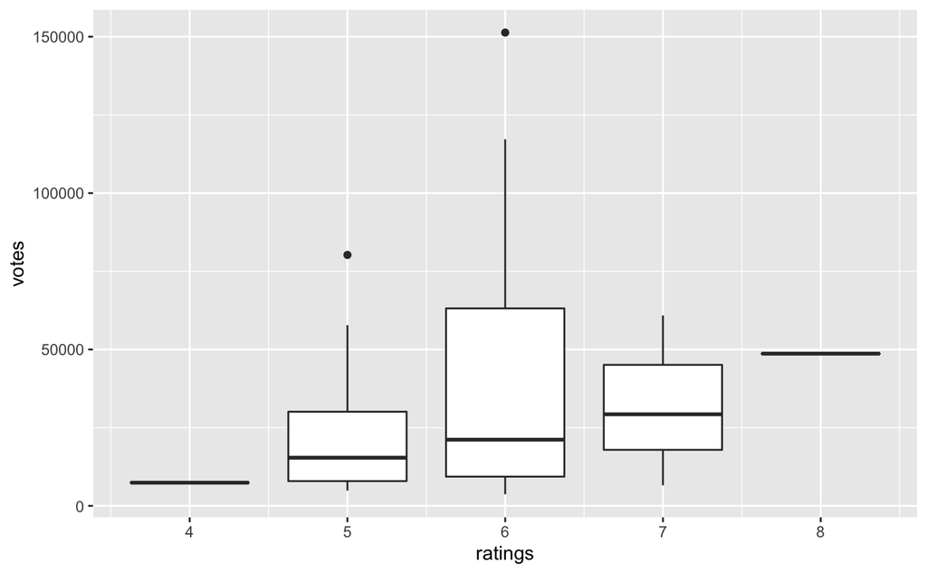

```r
ggplot(imdbmovies,
       aes(x = ratings, y = votes, group = ratings)) +
  geom_boxplot()
```